# Michael Ghattas / INFO - 1201 / SUM - 2021 / Final Project

# **Stereotypes**

#### *Stereotypes can be seen as the problem child of human survival instinct. Though sometimes help avoid unwanted outcomes, stereotypes can steer a person away from an objectives reality. Unfortunately, this is as much true in the real world as it is in the fictional world. Accordingly, this project aims to elaborate on the importance of developing one's computational thinking and objective analysis to avoid negative stereotypes.*

> “We slaughter one another in our words and attitudes. We slaughter one another in the stereotypes and mistrust that linger in our heads, and the words of hate we spew from our lips.” - Nelson Mandela

## **If you had to make a general guess, what would you say is the most dominant *Hair-Color* and *Eye-Color* that *Bad-Guys* represent in the Marvel & DC universes? How about the *Good-Guys*?**

#### *- Let's dive into the data for a closer look!*

```python
# Importing Pandas and Numpy libraries
import pandas as pd
import numpy as np
import matplotlib.pyplot as plt

# The following allows us to display our graphs in line
%matplotlib inline

# Removing warnings
import warnings
warnings.filterwarnings('ignore')

# Reading data from file and marking "Year" as an integer rather than a string
superheroes = pd.read_csv("superheroData.csv", parse_dates = ["FIRST_YEAR"])

# Printing the data for a quick look
superheroes.head()
```

|  | UNIVERSE | page_id | name | urlslug | ID | ALIGN | IS_AVENGER | AVENGER_STATUS | AVENGER_YEAR | EYES | ... | SEX | SEXUALITY | ALIVE | APPEARANCES | FIRST_MONTH | FIRST_YEAR | DECEASED | RESURRECTED | Unnamed: 19 | Unnamed: 20 |
| --- | --- | --- | --- | --- | --- | --- | --- | --- | --- | --- | --- | --- | --- | --- | --- | --- | --- | --- | --- | --- | --- |
| 0 | DC | 1702 | Richard Occult (New Earth) | Richard_Occult_(New_Earth) | Secret Identity | ND | NO | ND | ND | Grey Eyes | ... | Male Characters | Heterosexual Characters | Living Characters | 125 | October | 1935 | ND | ND | NaN | NaN |
| 1 | DC | 158200 | Arthur Pendragon (New Earth) | Arthur_Pendragon_(New_Earth) | Public Identity | Good Characters | NO | ND | ND | Brown Eyes | ... | Male Characters | Heterosexual Characters | Living Characters | 41 | February | 1936 | ND | ND | NaN | NaN |
| 2 | DC | 289378 | Bedivere (New Earth) | Bedivere_(New_Earth) | ND | ND | NO | ND | ND | ND | ... | Male Characters | Heterosexual Characters | Living Characters | ND | February | 1936 | ND | ND | NaN | NaN |
| 3 | DC | 11333 | Franklin Delano Roosevelt (New Earth) | Franklin_Delano_Roosevelt_(New_Earth) | Public Identity | Good Characters | NO | ND | ND | ND | ... | Male Characters | Heterosexual Characters | Living Characters | 52 | March | 1936 | ND | ND | NaN | NaN |
| 4 | DC | 342641 | Gareth (New Earth) | Gareth_(New_Earth) | ND | ND | NO | ND | ND | ND | ... | Male Characters | Heterosexual Characters | Living Characters | 1 | February | 1936 | ND | ND | NaN | NaN |

5 rows × 21 columns

#### *When dealing with a large amount of information, we are bound to have over-categorization and unfiltered noise. Therefore it is essential to decompose the gathered data, abstract the answers we are trying to find, and build a roadmap to reach our desired report. Consequently, we aggregated the various colors in the data and grouped them based on a White, Black, Grey, and ROYGBIV scale.*

```python
# Replacing repeated variables and grouping unhelpful info
# Eyes
superheroes = superheroes.replace("ND", "Unknown")
superheroes = superheroes.replace("No Eyes", "Unknown")
superheroes = superheroes.replace("One Eye", "Unknown")
superheroes = superheroes.replace("Variable", "Unknown")
superheroes = superheroes.replace("Compound Eyes", "Unknown")
superheroes = superheroes.replace("Photocellular Eyes", "Unknown")
superheroes = superheroes.replace("Variable Eyes", "Unknown")
superheroes = superheroes.replace("Multiple Eyes", "Unknown")
superheroes = superheroes.replace("Multiple Eyes", "Unknown")
superheroes = superheroes.replace("Hazel Eyes; White Eyes", "Unknown")

superheroes = superheroes.replace("Brown Eyes formerly Blue Eyes", "Brown Eyes")
superheroes = superheroes.replace("Red Eyes formerly Blue Eyes", "Red Eyes")
superheroes = superheroes.replace("Brown Eyes formerly Amber formerly Green", "Brown Eyes")
superheroes = superheroes.replace("Blue Eyes formerly Green", "Blue Eyes")
superheroes = superheroes.replace("Yellow Eyeballs", "Yellow Eyes")
superheroes = superheroes.replace("Black Eyeballs", "Black Eyes")
superheroes = superheroes.replace("Magenta Eyes", "Red Eyes")
superheroes = superheroes.replace("Auburn Eyes", "Brown Eyes")
superheroes = superheroes.replace("Silver Eyes", "Grey Eyes")
superheroes = superheroes.replace("Amber Eyes", "Yellow Eyes")
superheroes = superheroes.replace("Gold Eyes", "Yellow Eyes")
superheroes = superheroes.replace("Pink Eyes", "Red Eyes")
superheroes = superheroes.replace("Hazel Eyes", "Brown Eyes")
superheroes = superheroes.replace("Purple Eyes", "Violet Eyes")
superheroes = superheroes.replace("Brown Eyes", "Orange Eyes")

# Hair
superheroes = superheroes.replace("No Hair", "Unknown")
superheroes = superheroes.replace("Bald", "Unknown")
superheroes = superheroes.replace("Bald formerly Brown Hair and sometimes Blond Hair", "Unknown")
superheroes = superheroes.replace("Dyed Hair", "Unknown")
superheroes = superheroes.replace("Brown or Green Hair", "Unknown")
superheroes = superheroes.replace("Variable Hair", "Unknown")

superheroes = superheroes.replace("Strawberry Blond Hair", "Blond Hair")
superheroes = superheroes.replace("Yellow Hair", "Blond Hair")
superheroes = superheroes.replace("Gold Hair", "Blond Hair")
superheroes = superheroes.replace("Platinum Blond Hair", "Blond Hair")
superheroes = superheroes.replace("Reddish Blond Hair", "Blond Hair")
superheroes = superheroes.replace("Strawberry Blond", "Blond Hair")
superheroes = superheroes.replace("No Hair formerly Blond Hair", "Blond Hair")
superheroes = superheroes.replace("Light Brown Hair", "Brown Hair")
superheroes = superheroes.replace("Reddish Brown Hair", "Brown Hair")
superheroes = superheroes.replace("Orange-brown Hair", "Brown Hair")
superheroes = superheroes.replace("Brown Hair dyed Black", "Brown Hair")
superheroes = superheroes.replace("Brown Hair; No Hair", "Brown Hair")
superheroes = superheroes.replace("Red Hair formerly dyed Black", "Red Hair")
superheroes = superheroes.replace("Black Hair (shaved bald)", "Black Hair")
superheroes = superheroes.replace("Black Hair with White streaks", "Black Hair")
superheroes = superheroes.replace("Gray Hair dyed Black", "Grey Hair")
superheroes = superheroes.replace("Black Hair shaved bald", "Black Hair")
superheroes = superheroes.replace("Black Hair (shaved)", "Black Hair")
superheroes = superheroes.replace("Gray Hair", "Grey Hair")
superheroes = superheroes.replace("Blond Hair", "Yellow Hair")
superheroes = superheroes.replace("Auburn Hair", "Brown Hair")
superheroes = superheroes.replace("Purple Hair", "Violet Hair")
superheroes = superheroes.replace("Pink Hair", "Red Hair")
superheroes = superheroes.replace("Silver Hair", "Grey Hair")
superheroes = superheroes.replace("Magenta Hair", "Red Hair")
superheroes = superheroes.replace("Bronze Hair", "Brown Hair")
superheroes = superheroes.replace("Brown Hair", "Orange Hair")

# Align
superheroes = superheroes.replace("Neutral Characters", "Unknown")
superheroes = superheroes.replace("Reformed Criminals", "Good Characters")

# Droping all the Unknowns
superheroes = superheroes.drop(superheroes[superheroes.EYES == "Unknown"].index)
superheroes = superheroes.drop(superheroes[superheroes.HAIR == "Unknown"].index)
superheroes = superheroes.drop(superheroes[superheroes.ALIGN == "Unknown"].index)
```

#### *Once our data has been scrubbed and cleaned for analysis, we will need to redefine its categorization and labeling for future use.*

#### *- Let's see what our data looks like after preparation.*

```python
# Here we count all the unique values in the 'Eyes' column in order to get the breakdown of colors
eyes_count = superheroes["EYES"].value_counts()
print("-------------------------")
print("       Eye Colors\n-------------------------\n")
print(eyes_count)

# Here we count all the unique values in the 'Hair' column in order to get the breakdown of colors
hair_count = superheroes["HAIR"].value_counts()
print("\n-------------------------")
print("       Hair Colors\n-------------------------\n")
print(hair_count)

# Here we count all the unique values in the 'Align' column in order to get the breakdown of colors
align_count = superheroes["ALIGN"].value_counts()
print("\n--------------------------")
print("   Character Alignment\n--------------------------\n")
print(align_count)
```

```
-------------------------
       Eye Colors
-------------------------

Blue Eyes      2192
Orange Eyes    2041
Green Eyes      507
Black Eyes      493
Red Eyes        291
White Eyes      188
Yellow Eyes     146
Grey Eyes        87
Violet Eyes      40
Name: EYES, dtype: int64

-------------------------
       Hair Colors
-------------------------

Black Hair     2160
Orange Hair    1431
Yellow Hair    1087
Red Hair        467
White Hair      422
Grey Hair       239
Green Hair       93
Blue Hair        44
Violet Hair      42
Name: HAIR, dtype: int64

--------------------------
   Character Alignment
--------------------------

Good Characters    3372
Bad Characters     2615
Name: ALIGN, dtype: int64
```

#### *Next, we will need to visualize our findings by cross-correlating the three factors we are looking at; Hair Color, Eye Color, and Alignment.*

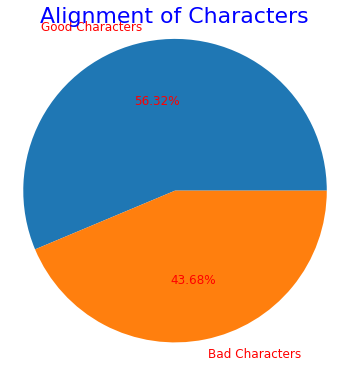

```python
# Setting values for visualization in a pie chart
align_counts = superheroes["ALIGN"].value_counts()

# Here we are able to control the visual size of our figures
plt.rcParams["figure.figsize"] = (6, 6)
plt.rcParams['text.color'] = 'r'

# Using a pie chart, we aim to take a better look at the spread
# autopct, automatically generates percent values, with each piece of the pie having a minimum representation
align_counts.plot(kind = "pie", autopct = "%1.2f%%", subplots = True, fontsize = 12)
plt.title("Alignment of Characters", color = "blue", fontsize = 22)

# Making the plot have even axes so the pie chart is perfectly circular
plt.axis("equal")

# Getting rid of the y-axis label - http://stackoverflow.com/questions/34094596/python-matplotlib-pyplot-pie-charts-how-to-remove-the-label-on-the-left-side
# These modifications also help make the bar chart look nicer and more readable
plt.axes().set_ylabel('')

# Displaying the plot
plt.show()
```

### **We can see the good guys outnumber the bad ones!**

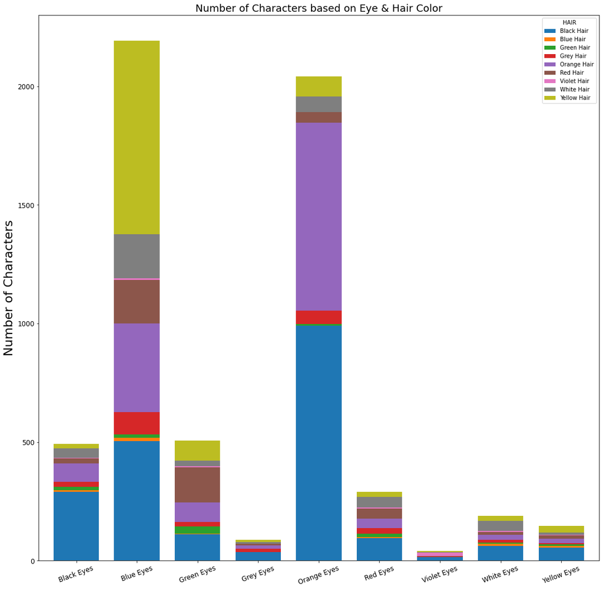

```python
# Here we are able to control the visual size of our figures
plt.rcParams["figure.figsize"] = (18, 18)
plt.rcParams['text.color'] = 'k'

# Setting up the needed data frame
colors_count = pd.crosstab(superheroes['EYES'], superheroes['HAIR'])

# Using a bar chart, we aim to take a better look at the eye/hair color distribution
colors_count.plot(kind= 'bar', stacked = True, width = 0.75)
plt.title('Number of Characters based on Eye & Hair Color', fontsize = 18)
plt.xlabel('')
plt.ylabel("Number of Characters", fontsize = 22)
plt.xticks(rotation = 20, fontsize = 12)
plt.yticks(fontsize = 12)

# Displaying the plot
plt.show()
```

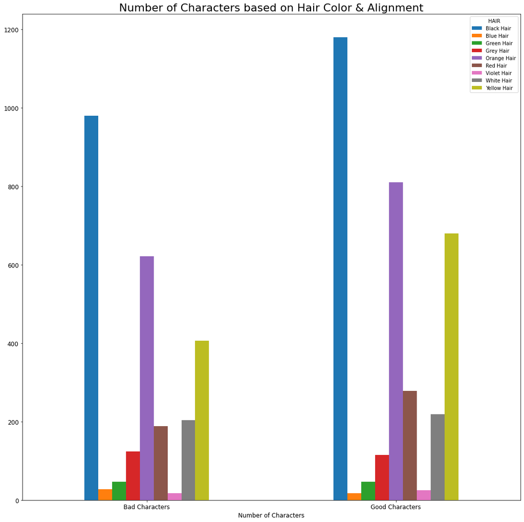

```python
# Setting up the data frame we need for our plot
align_eyes = pd.crosstab(superheroes["ALIGN"], superheroes["HAIR"])
align_eyes.plot(kind = 'bar')

# Creating our area plot for the given variables
plt.title("Number of Characters based on Hair Color & Alignment", fontsize = 22)
plt.xticks(rotation = 0, fontsize = 12)
plt.yticks(fontsize = 12)
plt.xlabel("Number of Characters", fontsize = 12)
plt.ylabel('')

# Displaying the plot
plt.show()
```

## **Below are the two top trends:**

### 1. *Black-Hair* is the first dominant color for *Bad-Guys*, but there are more *Good-Guys* with *Black-Hair* than bad.

### 2. *Orange-Hair* is the second dominant color for *Bad-Guys*, but there are more *Good-Guys* with *Orange-Hair* than bad.

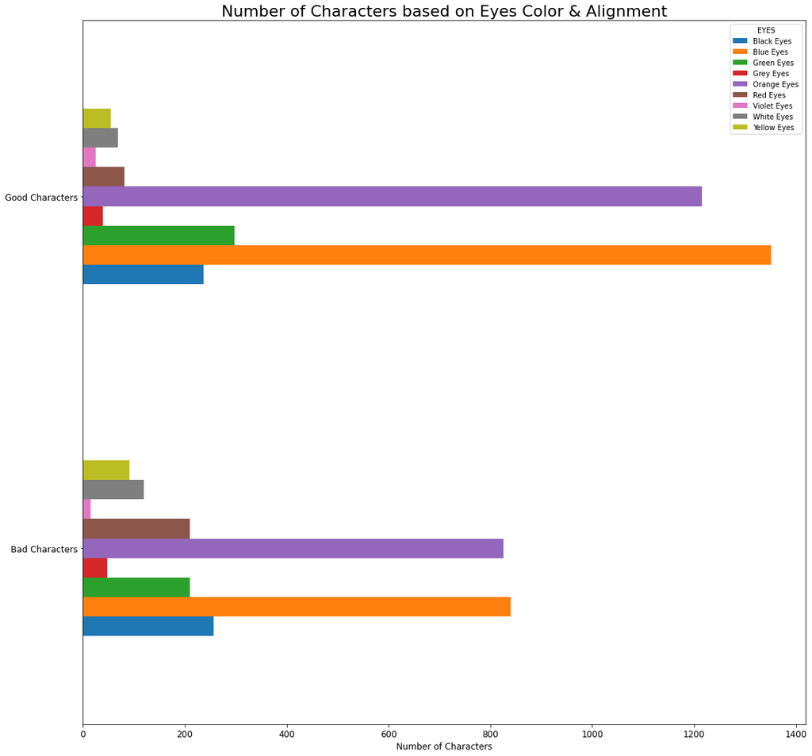

```python
# Setting up the data frame we need for our plot
align_eyes = pd.crosstab(superheroes["ALIGN"], superheroes["EYES"])
align_eyes.plot(kind = 'barh')

# Creating our area plot for the given variables
plt.title("Number of Characters based on Eyes Color & Alignment", fontsize = 22)
plt.xticks(rotation = 0, fontsize = 12)
plt.yticks(fontsize = 12)
plt.xlabel("Number of Characters", fontsize = 12)
plt.ylabel('')

# Displaying the plot
plt.show()
```

## **Below are the two top trends:**

### 1. *Blue-Eyes* is the first dominant color for *Bad-Guys*, but there are more *Good-Guys* with *Blue-Eyes* than bad.

### 2. *Orange-Eyes* is the second dominant color for *Bad-Guys*, but there are more *Good-Guys* with *Orange-Eyes* than bad.

# **Conclusion:**

## Thank you for participating in this journey, and I leave you with an article about a disease that plagues our minds across the world with no exceptions: [How Confirmation Bias Works](https://www.verywellmind.com/what-is-a-confirmation-bias-2795024)